# Machine Learning Exercise Movements

Andrew Washbrun

February 27, 2017

## Executive Summary

The Internet of Things allows the classification of previously undocumented activities, such as exercise routines, in gross detail allowing machine learning prediction models to detect which type of exercise a user is attempting. Utilizing data from the Weight Lifting Exercise Dataset, classification and random forest prediciton models can predict what type of dumbell exercise a user is attempting based on accelerometer data gather on the user’s arm, forearm, waist and dumbell.

## Data Wrangling

Accelerometer data is download from dataset’s website: http://groupware.les.inf.puc-rio.br/har . Training and validation sets are imported and cleaned up to remove uninterprettable values like NA, #DIV/0!, and empty values. Then the first several columns are removed because they contain non-movement related data like user and timestamp. Then the training set is split 70/30 into a training and testing set to prevent model overfitting for the validation set.

```r
library(caret); library(rpart);library(rattle)
training <- read.csv('pml-training.csv', na.strings=c("NA","#DIV/0!",""))
validation <- read.csv('pml-testing.csv', na.strings=c("NA","#DIV/0!",""))


#wrangling data into variables
validation <- validation[, colSums(is.na(training)) == 0]
training <- training[, colSums(is.na(training)) == 0]
training <- training[,-c(1:7)]
validation <- validation[,-c(1:7)]


inTrain <- createDataPartition(y=training$classe,
                               p=0.7, list=FALSE)
trainingData <- training[inTrain,]
testingData <- training[-inTrain,]

names(trainingData)
```

```
##  [1] "roll_belt"            "pitch_belt"           "yaw_belt"
##  [4] "total_accel_belt"     "gyros_belt_x"         "gyros_belt_y"
##  [7] "gyros_belt_z"         "accel_belt_x"         "accel_belt_y"
## [10] "accel_belt_z"         "magnet_belt_x"        "magnet_belt_y"
## [13] "magnet_belt_z"        "roll_arm"             "pitch_arm"
## [16] "yaw_arm"              "total_accel_arm"      "gyros_arm_x"
## [19] "gyros_arm_y"          "gyros_arm_z"          "accel_arm_x"
## [22] "accel_arm_y"          "accel_arm_z"          "magnet_arm_x"
## [25] "magnet_arm_y"         "magnet_arm_z"         "roll_dumbbell"
## [28] "pitch_dumbbell"       "yaw_dumbbell"         "total_accel_dumbbell"
## [31] "gyros_dumbbell_x"     "gyros_dumbbell_y"     "gyros_dumbbell_z"
## [34] "accel_dumbbell_x"     "accel_dumbbell_y"     "accel_dumbbell_z"
## [37] "magnet_dumbbell_x"    "magnet_dumbbell_y"    "magnet_dumbbell_z"
## [40] "roll_forearm"         "pitch_forearm"        "yaw_forearm"
## [43] "total_accel_forearm"  "gyros_forearm_x"      "gyros_forearm_y"
## [46] "gyros_forearm_z"      "accel_forearm_x"      "accel_forearm_y"
## [49] "accel_forearm_z"      "magnet_forearm_x"     "magnet_forearm_y"
## [52] "magnet_forearm_z"     "classe"
```

The remaining predictors are accelerometer data from the user and the “classe” variable which is the exercise type.

## Recursive Partitioning

Classification trees partition data into logical trees where successive predictors lead to a classification. The classifiers are built such that the root of each branch contains a sufficiently “pure” class, meanining data with identical predictor values will be evaluated to that root class.

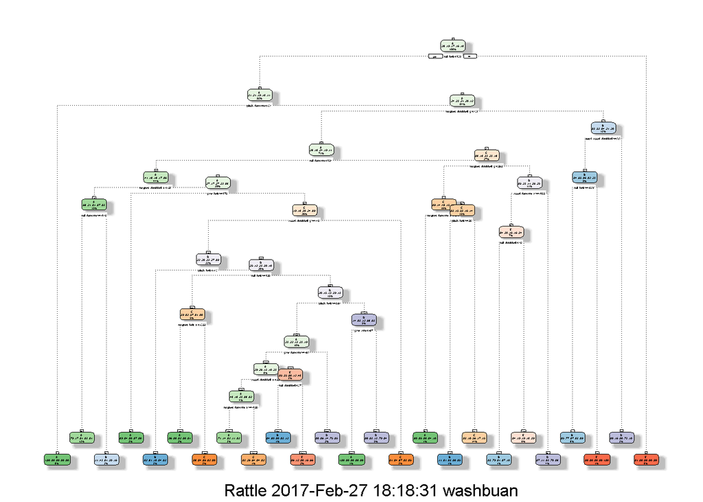

```r
#tree prediction
modFit <- rpart(classe ~ ., method='class', data=trainingData)
fancyRpartPlot(modFit)
```

```r
predictions <- predict(modFit,testingData,type='class')
confusionStats <- confusionMatrix(predictions,testingData$classe)
confusionStats
```

```
## Confusion Matrix and Statistics
##
##           Reference
## Prediction    A    B    C    D    E
##          A 1512  175   19   59   14
##          B   60  691   52   75   80
##          C   45   91  830  142  138
##          D   22   91   58  617   63
##          E   35   91   67   71  787
##
## Overall Statistics
##
##                Accuracy : 0.754
##                  95% CI : (0.7427, 0.7649)
##     No Information Rate : 0.2845
##     P-Value [Acc > NIR] : < 2.2e-16
##
##                   Kappa : 0.6882
##  Mcnemar's Test P-Value : < 2.2e-16
##
## Statistics by Class:
##
##                      Class: A Class: B Class: C Class: D Class: E
## Sensitivity            0.9032   0.6067   0.8090   0.6400   0.7274
## Specificity            0.9366   0.9437   0.9144   0.9524   0.9450
## Pos Pred Value         0.8499   0.7213   0.6661   0.7250   0.7488
## Neg Pred Value         0.9605   0.9091   0.9577   0.9311   0.9390
## Prevalence             0.2845   0.1935   0.1743   0.1638   0.1839
## Detection Rate         0.2569   0.1174   0.1410   0.1048   0.1337
## Detection Prevalence   0.3023   0.1628   0.2117   0.1446   0.1786
## Balanced Accuracy      0.9199   0.7752   0.8617   0.7962   0.8362
```

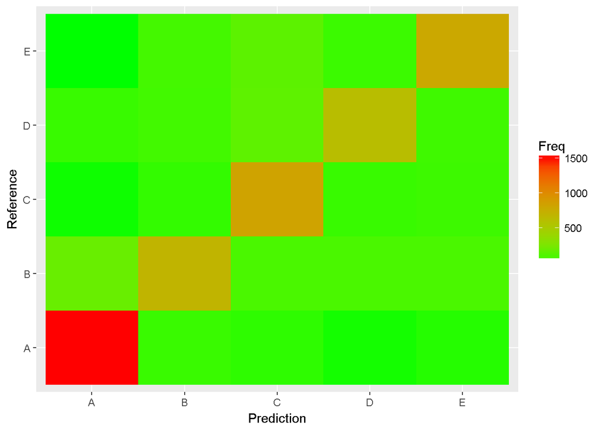

```r
tableStats <- as.data.frame(confusionStats$table)
ggplot(aes(Prediction,Reference),data=tableStats) +
  geom_tile(aes(fill=Freq)) + scale_fill_gradient(low="green", high="red")
```

## Random Forest

Random forests extend the idea of classification trees with random bootstrapping. By resampling and averaging models, a more robust decision tree is created.

```r
#Random Forest
library(randomForest)
forestModel <- randomForest(classe~.,data=trainingData)
forestPredictions <- predict(forestModel,testingData,type='class')
forestConfStats <- confusionMatrix(forestPredictions,testingData$classe)
forestConfStats
```

```
## Confusion Matrix and Statistics
##
##           Reference
## Prediction    A    B    C    D    E
##          A 1672    8    0    0    0
##          B    1 1130    5    0    0
##          C    0    1 1020   13    0
##          D    0    0    1  950    2
##          E    1    0    0    1 1080
##
## Overall Statistics
##
##                Accuracy : 0.9944
##                  95% CI : (0.9921, 0.9961)
##     No Information Rate : 0.2845
##     P-Value [Acc > NIR] : < 2.2e-16
##
##                   Kappa : 0.9929
##  Mcnemar's Test P-Value : NA
##
## Statistics by Class:
##
##                      Class: A Class: B Class: C Class: D Class: E
## Sensitivity            0.9988   0.9921   0.9942   0.9855   0.9982
## Specificity            0.9981   0.9987   0.9971   0.9994   0.9996
## Pos Pred Value         0.9952   0.9947   0.9865   0.9969   0.9982
## Neg Pred Value         0.9995   0.9981   0.9988   0.9972   0.9996
## Prevalence             0.2845   0.1935   0.1743   0.1638   0.1839
## Detection Rate         0.2841   0.1920   0.1733   0.1614   0.1835
## Detection Prevalence   0.2855   0.1930   0.1757   0.1619   0.1839
## Balanced Accuracy      0.9985   0.9954   0.9956   0.9924   0.9989
```

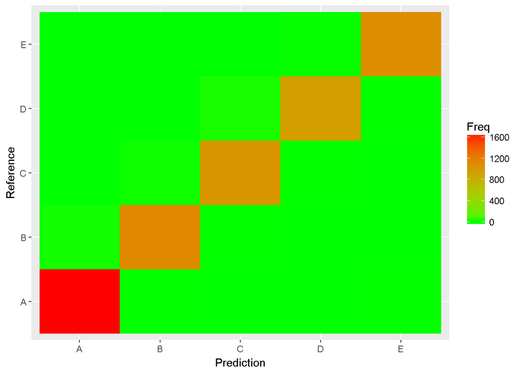

```r
forestTableStats <- as.data.frame(forestConfStats$table)
ggplot(aes(Prediction,Reference),data=forestTableStats) +
  geom_tile(aes(fill=Freq)) + scale_fill_gradient(low="green", high="red")
```